# Crime in Wisconsin

## Introduction

The question of whether there is a correlation between poverty and crime rate is complex and argumentative. Some argue that crime is driven by lack of social justice, imbalanced love from families, or mental health issues; others contend that induced crime rate is parallel to an increase in income inequality. While both sides may be correct, in our project, we will focus on crimes in Wisconsin as we have been seeing more and more crime in the news and wanted to observe the crime levels in Wisconsin by county. We wanted to answer the question: What is the relationship between poverty and crime? Our group has taken the stance that crime will be higher in wealthier metropolitan counties due to the fact they have a high population density. To answer this question, we are defining wealth in each county in two ways: Median income and percent in poverty. From that, we plan to use a 95% confidence interval and linear regression to find how those factors affect the various crimes (Assault, Arson, Murders, Larceny, Rape, and Robberies).

## Background

> About the raw Data:

The data set we’re using is a combination of data from the Census Bureau and Wisconsin Department of Justice. The census data gave us county level statistics for poverty and income in Wisconsin in 2019 which were created using a blend of census data and different estimation techniques. With the Wisconsin Department of Justice data set, we took only data from 2019 and pivoted the data wider in order to get counts based on the type of offense. We then joined the two data sets using county names and selected the variables of interest, such as violent crime, property crime, median household income, and population (which was calculated using the poverty rate).

> Data Citation:

Bureau, U.S.C. (2021) SAIPE state and County estimates for 2019, Census.gov. Available at: https://www.census.gov/data/datasets/2019/demo/saipe/2019-state-and-county.html (Accessed: April 17, 2023).  
Wisconsin Department of Justice. UCR Offense Data | Wisconsin Department of Justice. (n.d.). Retrieved April 17, 2023, from https://www.doj.state.wi.us/dles/bjia/ucr-offense-data

> Background Info:

Crime is often associated with levels of income, so we sought to see what the correlation really was in Wisconsin at the county level using poverty and crime rates at the county level

> Unusual factors:

There are a couple of counties that fall towards the extremes, for example one of the counties (Menominee) with the highest rates of poverty in Wisconsin has one of the lowest crime rates as well which slightly goes against the trend of the data. Another county, Milwaukee has an extremely high crime rate, however this rate is not as much of an outlier when compared to other counties. Where Menominee is a pretty strong outlier in poverty rate.

> Report Intent:

Intend to find the correlation between poverty rate and crime rates within counties in Wisconsin to try and help answer whether the two are related or not.

## Analysis

> First, to get introduced to the data, we wanted to just show the amount of crime in each county, organized by population

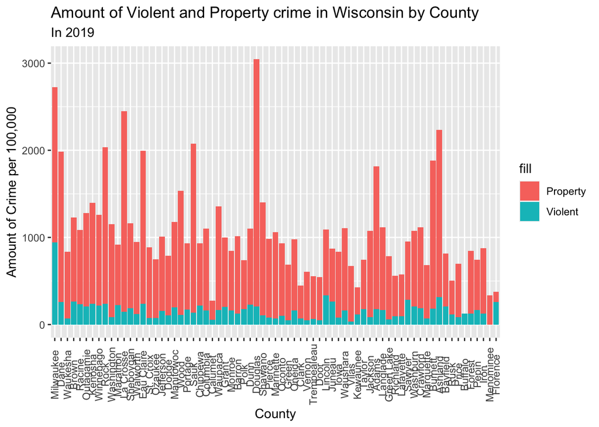

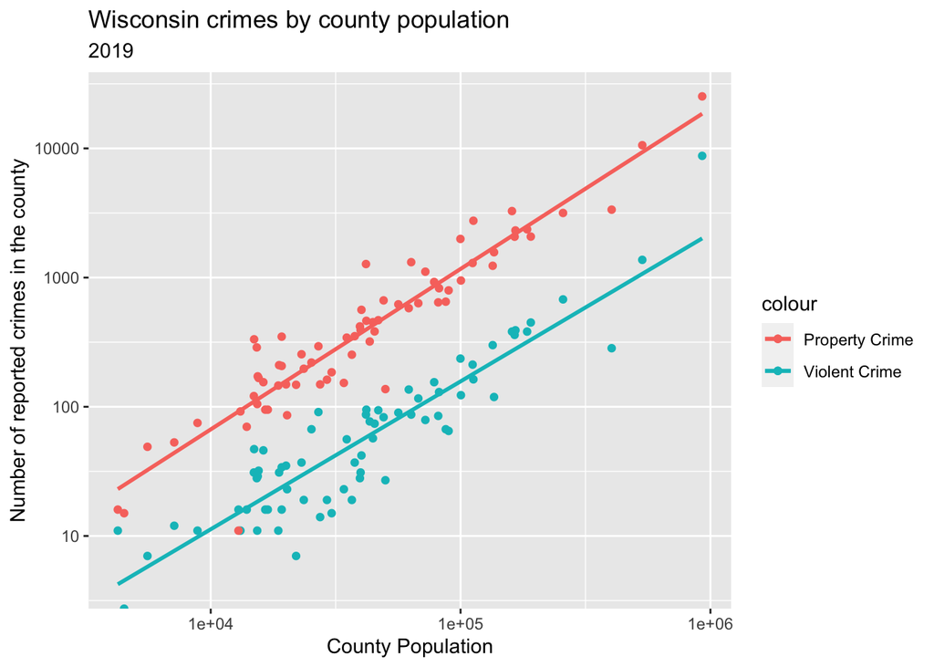

This graph further justifies the claim that Milwaukee has more crime than expected for a city in Wisconsin for the population as it is over the average for both property and violent crime. However, also suprising is that Dane county (the dot with the 2nd highest population) is very close to expected in both categories, which is not something you would expect from all the WISC alerts.

```r
cor(log10(finalDF$`Population`), log10(finalDF$`Property Crime`))
```

```
## [1] 0.9398603
```

> Next we looked at the relationship between total poverty and crime

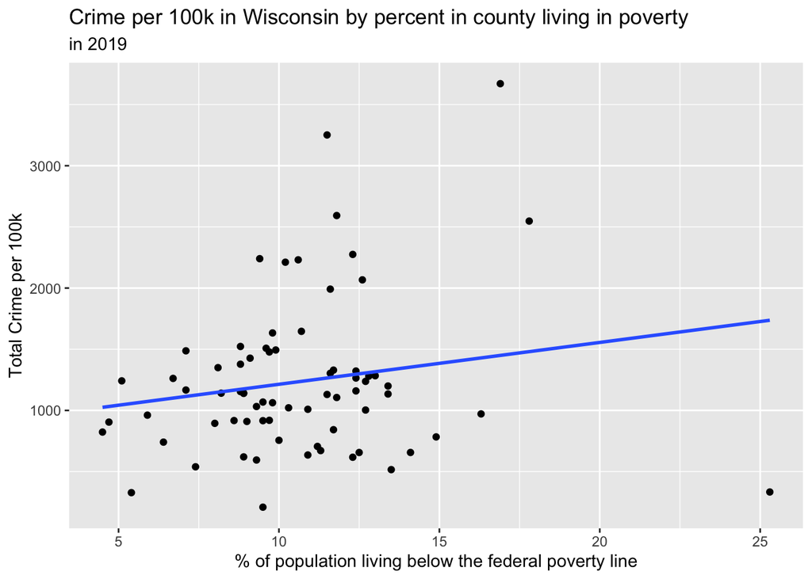

```r
cor(finalDF$`Poverty Percent, All Ages`, finalDF$`Property Crime` + finalDF$`Violent Crime`)
```

```
## [1] 0.1506642
```

```
##
## Call:
## lm(formula = totalCrime ~ `Poverty Percent, All Ages`, data = finalDF)
##
## Residuals:
##     Min      1Q  Median      3Q     Max
## -4323.5 -1446.2  -833.8    68.6 31356.6
##
## Coefficients:
##                             Estimate Std. Error t value Pr(>|t|)
## (Intercept)                   -691.7     1738.4  -0.398    0.692
## `Poverty Percent, All Ages`    198.8      157.1   1.266    0.210
##
## Residual standard error: 4231 on 69 degrees of freedom
## Multiple R-squared:  0.0227, Adjusted R-squared:  0.008536
## F-statistic: 1.603 on 1 and 69 DF,  p-value: 0.2098
```

The graph, R squared value, and the hypothesis test show that the relationship between poverty and crime lacks sufficent evidence to be considered linear. While the best fit line appears to slightly increase, this doesn’t necessary prove causation (or even correlation really) that higher poverty means higher crime. The hypothesis test shows that we don’t have sufficient evidence to claim that the actual value for slope is not zero (two sided t test, p = 0.210 > alpha = 0.05). A clear counter example is Menominee county, which has over a quarter of it’s people living in poverty, yet it has the 2nd lowest crime rate. This is very surprising as most people would assume that the higher the percent of the population that is poor, the more desperate they are, thus a higher crime, but the evidence doesn’t really support this.

> Next we looked at the relationship between child poverty and crime

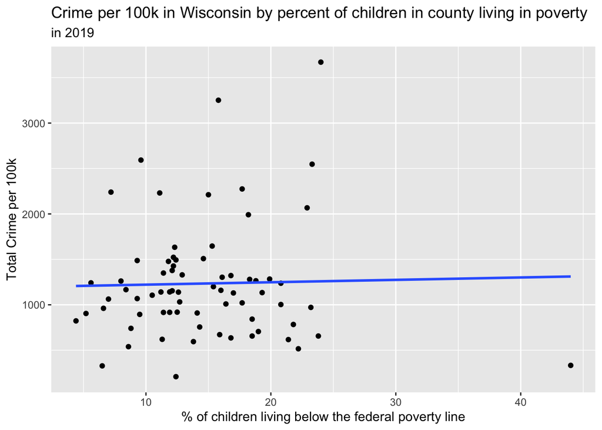

The graph alone clearly shows that there is little evidence for a linear relationship between childhood poverty rate and crime (at least in Wisconsin in 2019). This can be proven by doing a significance test:

```
##
## Call:
## lm(formula = totalCrime ~ `Poverty Percent, Age 0-17`, data = finalDF)
##
## Residuals:
##    Min     1Q Median     3Q    Max
##  -2466  -1339   -942   -237  32270
##
## Coefficients:
##                             Estimate Std. Error t value Pr(>|t|)
## (Intercept)                   883.16    1328.21   0.665    0.508
## `Poverty Percent, Age 0-17`    36.32      83.78   0.433    0.666
##
## Residual standard error: 4274 on 69 degrees of freedom
## Multiple R-squared:  0.002716,   Adjusted R-squared:  -0.01174
## F-statistic: 0.1879 on 1 and 69 DF,  p-value: 0.666
```

The hypothesis test again shows little evidence suggesting that the true slope of the relationship between childhood poverty and crime in Wisconsin is not 0 (2 sided hypothesis test, p = 0.666).

> Another relationship that could be intersting is that of median income of the household and the crime rate

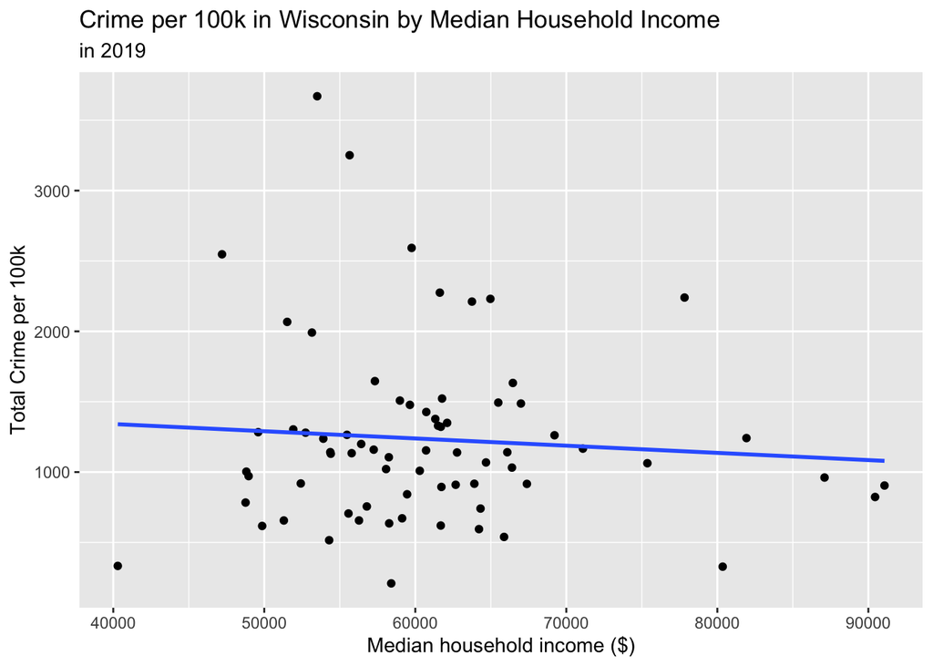

```r
cor(as.numeric(finalDF$`Median Household Income`), (finalDF$`Property Crime`) + (finalDF$`Violent Crime`))
```

```
## [1] 0.06441461
```

Again, the graph shows that there basically doesn’t exist a strong linear relationship between median household income and total crime in Wisconsin. This goes against the “common” knowledge that crime would increase the less wealthy the county is, but it looks like there is no relationship.

> Final Calculations

As the graphs above have demonstrated, there is little evidence to suggest that wealth and crime are correlated, thus making it almost impossible to predict the crime rate solely based on the household income or poverty rate of the county. Moreover, we discovered that the best single factor for predicting a crime rate is population, so we are now going to create a confidence interval. First step is to check normality:

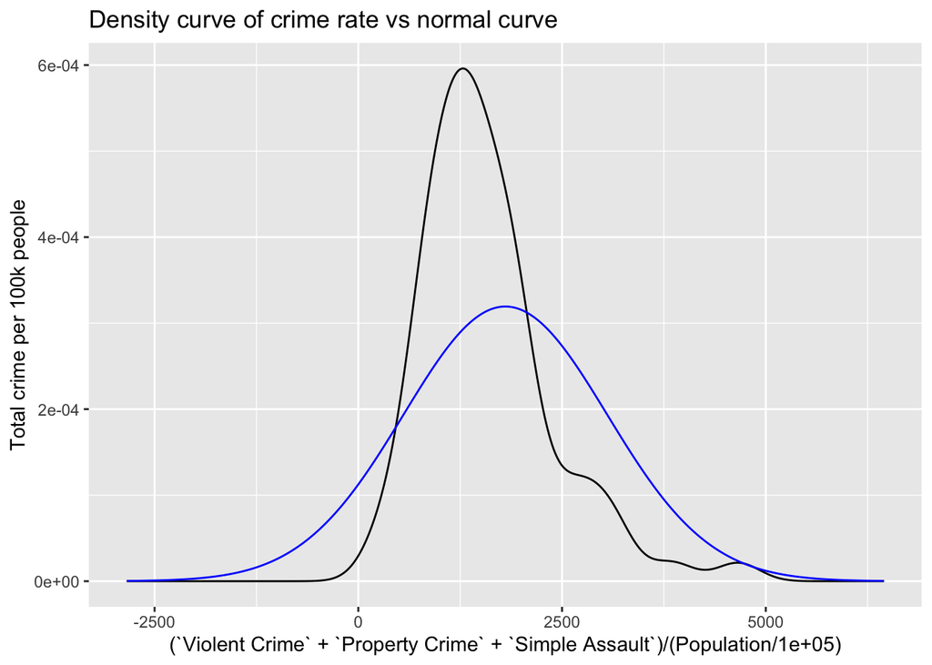

Clearly, the data is far from normal (as to be expected with the outliers), so a confidence interval would be inappropriate to do.

Finally, we wanted to conclusively answer our research question on the relationship between crime rate and wealth. Since the linear line of median income and wealth is molded by:

$$Y_i = \beta_0 + \beta_1 X_i +
\varepsilon_i$$

We state the hypothesis:
$$H_0: \beta_1 =
0$$
$$H_a: \beta_1 \neq 0$$

Calculations:
$$T = \frac{(\hat{\beta}_1
- H_0)}{SE} = 1.463$$
$$P_{value} = 2
* [1 - pt(T, 69)]= 0.148$$

The evidence is consistent(p = 0.148, two-sided t test) with $\beta_1$ equals to zero. Thus, there is no little evidence to suggest that the relationship between crime rate and poverty percentage in Wisconsin in not zero.

## Discussion

Based on the evidence provided, there is little to no linear relationship between poverty and crime rates in Wisconsin. While there appears to be a slight positive correlation between poverty and crime rates, the correlation coefficient of 0.1506642 suggests that this relationship is not particularly strong. Similarly, there is no evidence of a linear relationship between child poverty and crime rates in Wisconsin, and there appears to be no relationship between median household income and crime rates in Wisconsin. However, there are potential shortcomings to our analysis. According to Pew Research Center, most violent and property crimes are not reported in the US. [^1] This means that while the data still shows us a picture of the trend seen with crime and poverty in Wisconsin, we must acknowledge that there is potentially crime that is not accounted for by our analysis. Furthermore, these results are specific to Wisconsin in 2019, and further research with other factors may be needed to fully understand the complex relationship between poverty, wealth, and crime. Future direction for our research question will incorporate this as well as expanding our population from Wisconsin to the entirety of the US. We can potentially source our data from the US Census Bureau and the Bureau of Justice Statistics to provide a wealth of data on poverty, wealth, and crime at the national level as well as secondary sourcing from academic research. The analysis concludes that there is little evidence to support a linear relationship between poverty or household income and crime rates in Wisconsin. The primary evidence to support this includes correlation coefficients, regression models, and graphs that show the lack of a clear trend between these factors.

[^1]: https://www.pewresearch.org/short-reads/2020/11/20/facts-about-crime-in-the-u-s/#:~:text=Most%20violent%20and%20property%20crimes,are%20reported%20are%20not%20solved.